# Exploring the BRFSS data

gdolwell

5 January, 2018

## Setup

### Load packages

```r
library(ggplot2)
library(dplyr)
library(reshape2)
```

### Load data

Make sure your data and R Markdown files are in the same directory. When loaded your data file will be called `brfss2013`. Delete this note when before you submit your work.

```r
load("brfss2013.RData")
```

## Part 1: Data

From “https://cdc.gov/brfss”: “The Behavioral Risk Factor Surveillance System (BRFSS) is the nation’s premier system of health-related telephone surveys that collect state data about U.S. residents regarding their health-related risk behaviors, chronic health conditions, and use of preventive services. Established in 1984 with 15 states, BRFSS now collects data in all 50 states as well as the District of Columbia and three U.S. territories. BRFSS completes more than 400,000 adult interviews each year, making it the largest continuously conducted health survey system in the world.”

This data set will not allow for the establishment of causality. This is because it suffers from the lack of true randomization due to volunteer bias. The right censorship, those who did not finish the survey, will thus be the focus of this exploratory data analysis.

The survey, from my perspective, was exceedingly long and arduous. I would have hung up. Thus my question will be centered around those who hung up and their characteristics.

We will start with the loading and manipulation of the dataset in preparation for anaylsis.

```r
setwd("~/Code/R/stats_with_R/intro_prob_data/M1project/")
load("brfss2013.RData")
br.df <- as.data.frame(brfss2013)
rm(brfss2013)
```

From the codebook the variables of interest to us are: * sex : gender of respondent * _ageg5yr : reported age in 5 year categories * dispcode : did the respondent complete the interview

```r
br.df <- br.df %>% select(sex, X_ageg5yr, dispcode)
colnames(br.df)[1:3] <- c("gender", "age", "completed")
colnames(br.df)
```

```
## [1] "gender"    "age"       "completed"
```

## Part 2: Research questions

### Question 1: Complete cases

How many cases are there? Of those, how many actually completed the survey?

### Question 2:

Is there a difference among genders for those who completed the survey?

### Question 3:

Does age play a factor in the completion of the survey?

## Part 3: Exploratory data analysis

NOTE: Insert code chunks as needed by clicking on the “Insert a new code chunk” button (green button with orange arrow) above. Make sure that your code is visible in the project you submit. Delete this note when before you submit your work.

### Research quesion 1:

```r
l <- length(br.df[, 1]) # number of repsondents
c <- sum(br.df[, 3] != "Completed interview", na.rm = T) # not complete
c
```

```
## [1] 58548
```

```r
l
```

```
## [1] 491775
```

```r
c/l #proportion who did not finsih interview
```

```
## [1] 0.1190544
```

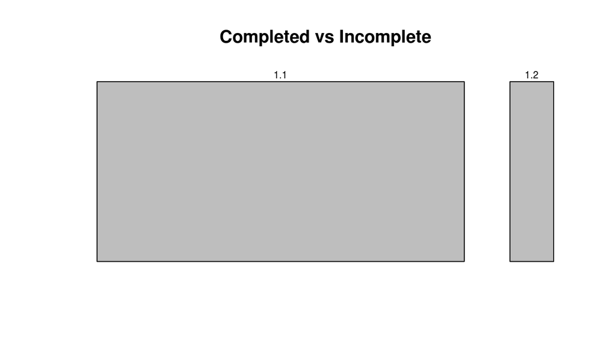

```r
mosaicplot(c(l, c), main = "Completed vs Incomplete")
```

We can see from the output that there were 491775 total people who picked up the phone, of those 58548 did not finish the whole survey or approximately 12%. This does not surprise me, and validates my suspisions.

## Research quesion 2:

```r
#subset br.df by gender
br.n <- br.df[ , 1] == "Male" # logical list Male = True
br.m <- br.df[br.n, ] # select those that are male
br.f <- br.df[!br.n, ] # selcet those that ar female
length(br.f[ , 1])
```

```
## [1] 290462
```

```r
length(br.m[ ,1])
```

```
## [1] 201320
```

```r
sum(is.na(br.df$gender))
```

```
## [1] 7
```

```r
length(br.f[ , 1]) /(length(br.f[ , 1]) + length(br.m[ , 1]))
```

```
## [1] 0.5906316
```

We see that there are 290462 females (59%) represented and 201320 males (41%), and 7 NAs.

Now that the dataset has been subsetted by gender lets look at the question. Ladies first:

```r
lf <- length(br.f[, 1]) #number of female repsondents
cf <- sum(br.df[ , 3] != "Completed interview", na.rm = T) #number of complete female interviews
lf
```

```
## [1] 290462
```

```r
cf
```

```
## [1] 58548
```

```r
cf / lf
```

```
## [1] 0.2015685
```

Now the Males:

```r
lm <- length(br.m[, 1]) #number of female repsondents
cm <- sum(br.m[ , 3] != "Completed interview", na.rm = T) #number of complete male interviews
lm
```

```
## [1] 201320
```

```r
cm
```

```
## [1] 26090
```

```r
cm / lm
```

```
## [1] 0.1295947
```

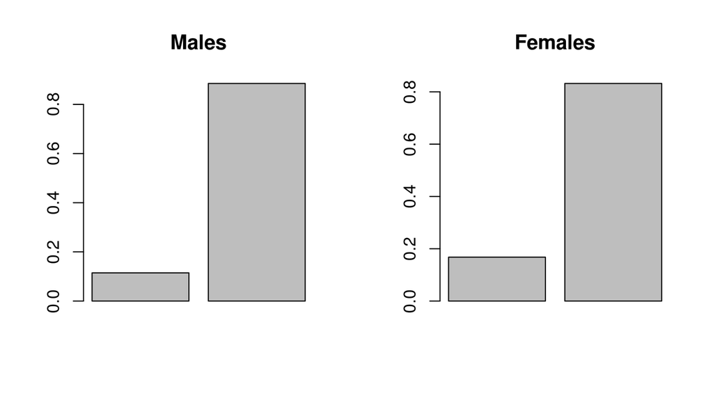

```r
par(mfrow = c(1,2))
barplot(c(cm / (cm+lm), lm / (cm +lm)), main = "Males")
barplot(c(cf / (cf+lf), lf / (cf +lf)), main = "Females")
```

### Research quesion 3:

```r
summary(br.df$age)
```

```
##    Age 18 to 24    Age 25 to 29    Age 30 to 34    Age 35 to 39
##           27202           22910           27213           28107
##    Age 40 to 44    Age 45 to 49    Age 50 to 54    Age 55 to 59
##           31508           36210           47173           52491
##    Age 60 to 64    Age 65 to 69    Age 70 to 74    Age 75 to 79
##           53659           49997           39967           30093
## Age 80 or older            NA's
##           40515            4730
```

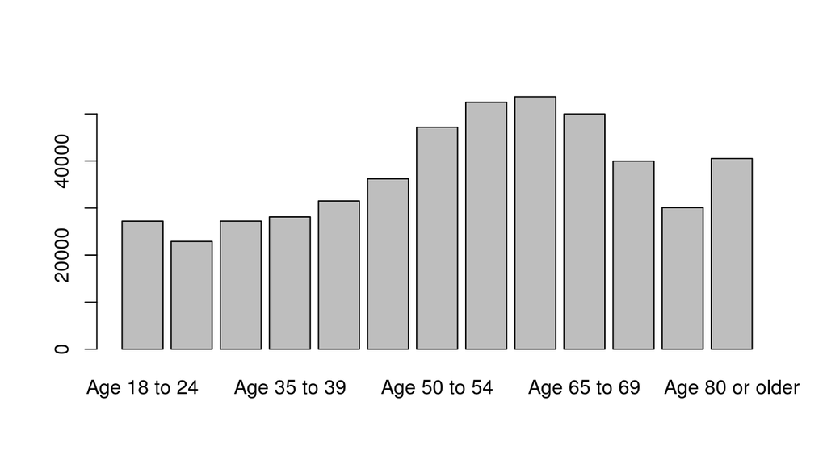

```r
plot(br.df$age)
```

So we can see at the onset there are 4730 NA’s with regard to age.

Lets partition by age.

```r
br.a <- br.df[is.na(br.df$age) == FALSE, ] #remove all age = NA
a18.24 <- (br.a[(br.a$age == "Age 18 to 24"), ])
a25.29 <- (br.a[(br.a$age == "Age 25 to 29"), ])
a30.34 <- (br.a[(br.a$age == "Age 30 to 34"), ])
a35.39 <- (br.a[(br.a$age == "Age 35 to 39"), ])
a40.44 <- (br.a[(br.a$age == "Age 40 to 44"), ])
a45.49 <- (br.a[(br.a$age == "Age 45 to 49"), ])
a50.54 <- (br.a[(br.a$age == "Age 50 to 54"), ])
a55.59 <- (br.a[(br.a$age == "Age 55 to 59"), ])
a60.64 <- (br.a[(br.a$age == "Age 60 to 64"), ])
a65.69 <- (br.a[(br.a$age == "Age 65 to 69"), ])
a70.74 <- (br.a[(br.a$age == "Age 70 to 74"), ])
a75.79 <- (br.a[(br.a$age == "Age 75 to 79"), ])
a80 <- (br.a[(br.a$age == "Age 80 or older"), ])
```

Now the proportion of completed interviews by age.

```r
c.age = data.frame(a18.24 = numeric(0), a25.30 = numeric(0), a31.34 =
                     numeric(0), a35.39 = numeric(0), a40.44 =
                     numeric(0), a45.49 = numeric(0), a50.54 =
                     numeric(0), a55.59 = numeric(0), a60.64 =
                     numeric(0), a65.69 = numeric(0), a70.74 =
                     numeric(0), a75.79 = numeric(0), a80 = numeric(0))

c.age[1,1] <- sum(a18.24$completed == "Completed interview") /
  length(a18.24[,1])
c.age[1,2] <- sum(a25.29$completed == "Completed interview") /
  length(a25.29[,1])
c.age[1,3] <- sum(a30.34$completed == "Completed interview") /
  length(a30.34[,1])
c.age[1,4] <- sum(a35.39$completed == "Completed interview") /
  length(a35.39[,1])
c.age[1,5] <- sum(a40.44$completed == "Completed interview") /
  length(a40.44[,1])
c.age[1,6] <- sum(a45.49$completed == "Completed interview") /
  length(a45.49[,1])
c.age[1,7] <- sum(a50.54$completed == "Completed interview") /
  length(a50.54[,1])
c.age[1,8] <- sum(a55.59$completed == "Completed interview") /
  length(a55.59[,1])
c.age[1,9] <- sum(a60.64$completed == "Completed interview") /
  length(a60.64[,1])
c.age[1,10] <- sum(a65.69$completed == "Completed interview") /
  length(a65.69[,1])
c.age[1, 11] <- sum(a70.74$completed == "Completed interview") /
  length(a70.74[,1])
c.age[1,12] <- sum(a75.79$completed == "Completed interview") /
  length(a75.79[,1])
c.age[1,13] <- sum(a80$completed == "Completed interview") /
  length(a80[,1])
new <- melt(c.age)
new
```

```
##    variable     value
## 1    a18.24 0.7908242
## 2    a25.30 0.7814928
## 3    a31.34 0.8222173
## 4    a35.39 0.8504643
## 5    a40.44 0.8704139
## 6    a45.49 0.8861088
## 7    a50.54 0.8940496
## 8    a55.59 0.9057553
## 9    a60.64 0.9117389
## 10   a65.69 0.9183351
## 11   a70.74 0.9099257
## 12   a75.79 0.9069219
## 13      a80 0.8953721
```

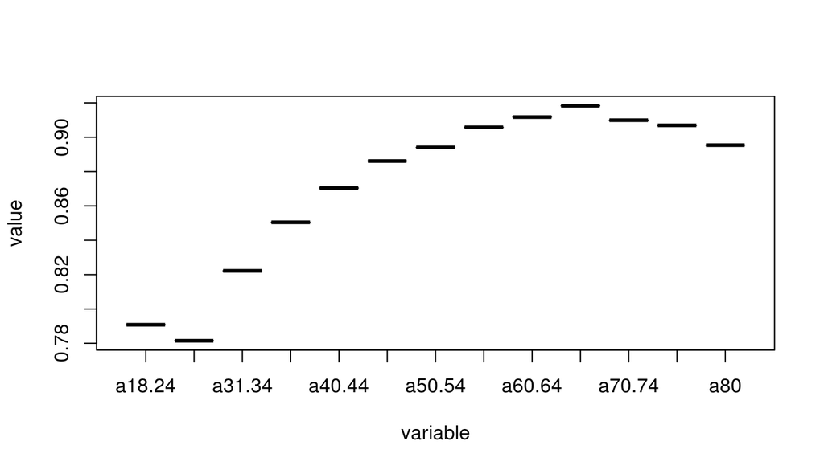

```r
plot(new)
```